# Problem Set 4

Rebecca Xi

3/04/2020

## Question #1: Mad Libs

ML 1) The standard deviation of median income, plus one, is 14456.7198499.

ML 2) Treasure County, Montana is located in the state of Montana.

ML 3) The upper bound for median income in Etowah County, Alabama (geoid = “01055”) is 45799.

## Question #2: Mapping

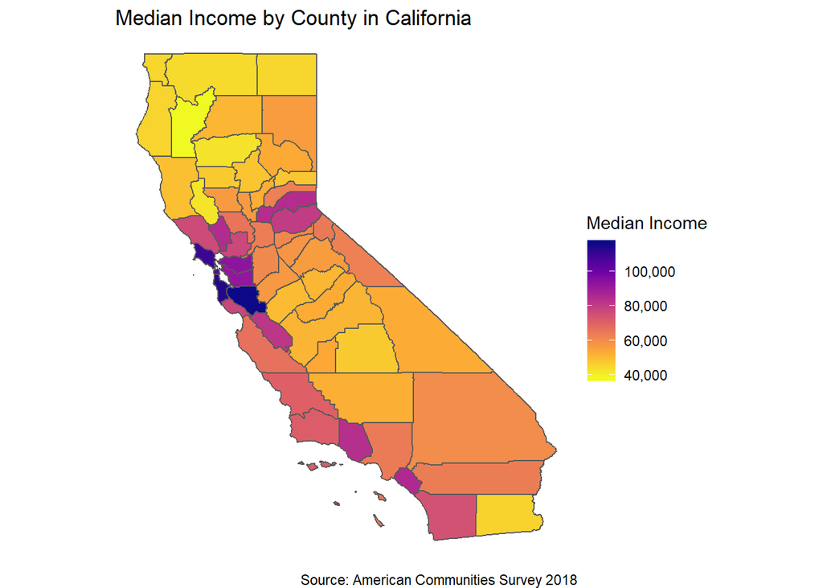

## Question #3: Publishing to Rpubs

https://rpubs.com/Becca63/pset_4_rpub

## Question #4: Understanding Tufte Reading

Most glaringly obvious is the wasted space on all sides of each slide. The header is unnecessarily large and padded too generously, and the font in general can be downsized to add room for more text. The overly large logo at the bottom is an example of pushy branding by LAO and contributes nothing to slide content. Bullet points throughout are misused. In many cases, the larger bullet points convey no meaningful information and serve only to introduce the sub-bullet points that follow; eliminating those header bullet points would provide space for more actual content. The numeric content on slide 9 is extremely simplified - the entire slide only conveys 8 numbers - and it is not immediately clear that the sales and use tax and the corporation tax numbers are also percentages, since the % sign is foregone. In general, it is difficult to understand the graphs and tables without any context. This holds true for the entire slide deck - it is impossible to glean a solid understanding of what’s going on just by looking at the slides, since they are standalone and don’t convey nearly enough information. In transforming the slide deck into an 8x11 handout, one should create an actual narrative with complete sentences, functional descriptions, as many paragraphs as needed to establish context, and transitional sentences as appropriate. The beginning of the handout should credit the actual curators of the content rather than simply “LAO” and provide a table of contents and comprehensive topic sentences throughout.

## Question #5: Functions

#### 5A

Rolling the alphabetical die 3 times yields o.

#### 5B

See RMarkdown file for function.

#### 5C

In 100 games, Alyssa rolls 39 vowels.

#### 5D

The probability that all four TF’s roll vowels is 0.54%. I would be extremely surprised if this occurred.

#### 5E

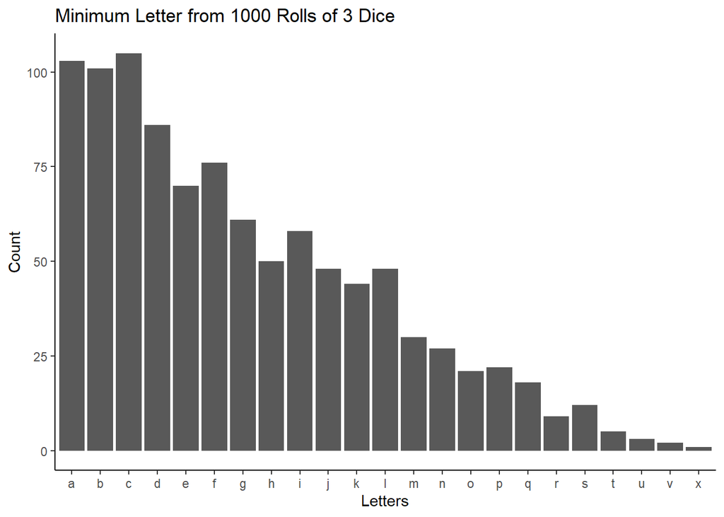

#### 5F

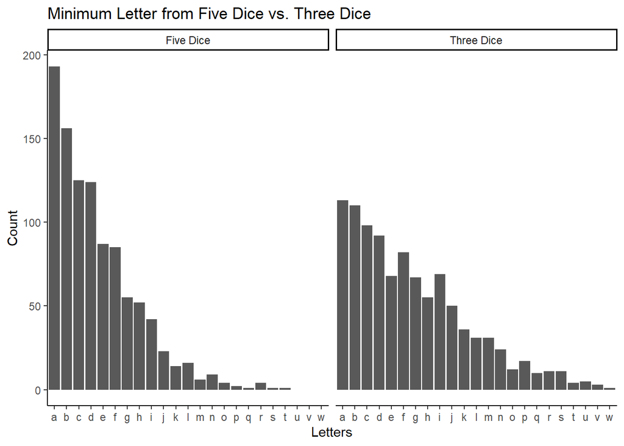

#### Colleagues:

- Grace Pan
- Brendan Chapuis
- Michael Chen
- Rachel Phan
- Brian Kim
- Hudson Miller
- Mak Famulari
- Rachel Auslander
- Josh Mathews